# DSC5103 Test 1

three questions, 10 points in total

Oct 2018

## NOTE:

This is an *individual* test. You can refer to whatever sources of information or materials, online or offline, but do not communicate with any other people. You can work on this file directly and fill in your answers/code below. Please submit the output RMD and HTML file (name your file like e0012345.rmd and e0012345.html if your NUS ID is e0012345) onto IVLE/Files/Student Submission/Test1 folder.

*Submission Deadline: Oct 6, 23:59:59*

Also, fill your info below. (**This is critical as your NUS user id will be used in determining your random sample of the data!**)

```r
student.name <- "LI LIPING"  # put your name here
student.id <- 0320278  # put only the numeric digits of your NUS user id here
```

## James Harden 2014/15

The file **JamesHarden2014.RData** is a dataset of shot records of an NBA (basketball) player James Harden in NBA regular season 2014-2015, obtained from the official NBA website http://stats.nba.com.

The data has been cleaned and prepared in an RData format. You can load the file by doing the following. After successfully loading the file, you should see a data frame called **data** with 1443 rows and 30 columns.

```r
load("JamesHarden2014.RData")  # load the data (make sure the .RData file is in your working directory!)
dim(data)  # show data dimensions
```

```
## [1] 1443   30
```

```r
summary(data)  # summary
```

```
##        GAME_ID     PERIOD   SHOT_NUMBER     PLAYER_ID          PLAYER_NAME         TEAM_ID               TEAM_NAME
##  0021400327:  32   1:418   Min.   : 1.00   201935:1443   James Harden:1443   1610612745:1443   Houston Rockets:1443
##  0021400217:  31   2:317   1st Qu.: 5.00
##  0021400324:  27   3:433   Median :10.00
##  0021401017:  27   4:265   Mean   :10.13
##  0021400411:  26   5: 10   3rd Qu.:14.00
##  0021400771:  25           Max.   :32.00
##  (Other)   :1275
##  MINUTES_REMAINING SECONDS_REMAINING              ACTION_TYPE           SHOT_TYPE                SHOT_ZONE_BASIC
##  Min.   : 0.000    Min.   : 0.00     Jump Shot          :590   3PT Field Goal:547   Right Corner 3       : 37
##  1st Qu.: 1.000    1st Qu.:13.00     Driving Layup Shot :288   2PT Field Goal:896   Restricted Area      :501
##  Median : 4.000    Median :28.00     Step Back Jump shot:190                        Above the Break 3    :484
##  Mean   : 4.077    Mean   :27.77     Layup Shot         :126                        Mid-Range            :267
##  3rd Qu.: 6.000    3rd Qu.:43.00     Pullup Jump shot   : 66                        In The Paint (Non-RA):128
##  Max.   :11.000    Max.   :59.00     Running Jump Shot  : 31                        Left Corner 3        : 25
##                                      (Other)            :152                        Backcourt            :  1
##                SHOT_ZONE_AREA        SHOT_ZONE_RANGE SHOT_DISTANCE       LOC_X              LOC_Y
##  Right Side(R)        :107    24+ ft.        :546    Min.   : 0.00   Min.   :-240.000   Min.   :-36.0
##  Center(C)            :824    Less Than 8 ft.:576    1st Qu.: 2.00   1st Qu.: -34.000   1st Qu.:  9.0
##  Left Side Center(LC) :194    16-24 ft.      :185    Median :16.00   Median :   0.000   Median : 86.0
##  Right Side Center(RC):237    8-16 ft.       :135    Mean   :13.51   Mean   :   7.374   Mean   :102.4
##  Left Side(L)         : 80    Back Court Shot:  1    3rd Qu.:24.00   3rd Qu.:  58.500   3rd Qu.:190.0
##  Back Court(BC)       :  1                           Max.   :46.00   Max.   : 242.000   Max.   :463.0
##
##                        MATCHUP     LOCATION W         FINAL_MARGIN       GAME_CLOCK      SHOT_CLOCK       DRIBBLES
##  DEC 11, 2014 - HOU @ SAC  :  32   H:745    W:1006   Min.   :-28.000   Min.   :  1.0   Min.   : 0.00   Min.   : 0.000
##  NOV 26, 2014 - HOU vs. SAC:  31   A:698    L: 437   1st Qu.: -3.000   1st Qu.: 92.5   1st Qu.: 6.70   1st Qu.: 1.000
##  MAR 19, 2015 - HOU vs. DEN:  27                     Median :  5.000   Median :216.0   Median :13.00   Median : 3.000
##  DEC 10, 2014 - HOU @ GSW  :  27                     Mean   :  3.635   Mean   :235.6   Mean   :12.16   Mean   : 5.027
##  DEC 22, 2014 - HOU vs. POR:  26                     3rd Qu.: 11.000   3rd Qu.:362.0   3rd Qu.:17.60   3rd Qu.: 8.000
##  APR 01, 2015 - HOU vs. SAC:  25                     Max.   : 36.000   Max.   :573.0   Max.   :24.00   Max.   :30.000
##  (Other)                   :1275
##    TOUCH_TIME     SHOT_RESULT        CLOSEST_DEFENDER CLOSEST_DEFENDER_PLAYER_ID CLOSE_DEF_DIST        PTS
##  Min.   :-5.100   FALSE:806   McLemore, Ben  :  40    203463 :  40               Min.   : 0.000   Min.   :0.000
##  1st Qu.: 2.000   TRUE :637   Tucker, PJ     :  34    200782 :  34               1st Qu.: 2.400   1st Qu.:0.000
##  Median : 4.700               Thompson, Klay :  30    202691 :  30               Median : 3.500   Median :0.000
##  Mean   : 5.765               Redick, JJ     :  29    200755 :  29               Mean   : 3.758   Mean   :1.026
##  3rd Qu.: 7.900               Green, Danny   :  23    201980 :  23               3rd Qu.: 4.600   3rd Qu.:2.000
##  Max.   :23.500               Wiggins, Andrew:  22    203952 :  22               Max.   :25.200   Max.   :3.000
##                               (Other)        :1265    (Other):1265
```

Every row is a shot attempt made by Harden. Here is a brief description of the columns.

- “GAME_ID”: unique id of the game;
- “PERIOD”: period of the game (NBA games have four periods, period==5 means extra time);
- “SHOT_NUMBER”: id of the shot in the game
- “PLAYER_ID”: Harden’s player id in the NBA database
- “PLAYER_NAME”: player name in text
- “TEAM_ID”: id of the team Houston Rockets
- “TEAM_NAME”: name of the team in text
- “MINUTES_REMAINING”: the number of minutes remaining in the period when the shot is taken
- “SECONDS_REMAINING”: the number of seconds remaining in the period when the shot is taken
- “ACTION_TYPE”: type of the shot action (categorical)
- “SHOT_TYPE”: type of the shot (categorical: 2-point or 3-point)
- “SHOT_ZONE_BASIC”: zone where the shot is taken (categorical)
- “SHOT_ZONE_AREA”: area where the shot is taken (categorical)
- “SHOT_ZONE_RANGE”: range of the shot (categorical)
- “SHOT_DISTANCE”: shot distance in feet
- “LOC_X”: X location of the player when taking the shot (in unknown unit)
- “LOC_Y”: Y location of the player when taking the shot (in unknown unit)
- “MATCHUP”: text description of the game
- “LOCATION”: location of the game (categorical: home or away)
- “W”: result of the game (categorical: win or loss)
- “FINAL_MARGIN”: final points difference between Rockets and the opponent
- “GAME_CLOCK”: time in game (in unknown unit)
- “SHOT_CLOCK”: number of seconds left to shoot (NBA’s 24-second rule)
- “DRIBBLES”: the distance that Harden dribbled before the shot (in feet)
- “TOUCH_TIME”: the time that Harden touches the ball before the shot (in seconds)
- “SHOT_RESULT”: result of the shot (categorical: True or False)
- “CLOSEST_DEFENDER”: name of the closest defender
- “CLOSEST_DEFENDER_PLAYER_ID”: id of the closest defender
- “CLOSE_DEF_DIST”: distance of the closest defender (in feet)
- “PTS”: number of points gained by the shot

### Q1. Analysis on **FINAL_MARGIN** (3 points)

The first question to investigate is on the relationship between the FINAL_MARGIN and LOCATION. In other words, does playing a home or away game have an effect on the final margin of the game?

#### a. Develop a regression model using **data** to answer the question above. (1 point)

```r
model1a <- lm(FINAL_MARGIN~LOCATION,data)
summary(model1a)
```

```
##
## Call:
## lm(formula = FINAL_MARGIN ~ LOCATION, data = data)
##
## Residuals:
##     Min      1Q  Median      3Q     Max
## -30.211  -6.211   1.789   7.789  30.789
##
## Coefficients:
##             Estimate Std. Error t value Pr(>|t|)
## (Intercept)   5.2107     0.4086  12.754  < 2e-16 ***
## LOCATIONA    -3.2580     0.5874  -5.546 3.47e-08 ***
## ---
## Signif. codes:  0 '***' 0.001 '**' 0.01 '*' 0.05 '.' 0.1 ' ' 1
##
## Residual standard error: 11.15 on 1441 degrees of freedom
## Multiple R-squared:  0.0209, Adjusted R-squared:  0.02022
## F-statistic: 30.76 on 1 and 1441 DF,  p-value: 3.47e-08
```

| *ANSWER of Q1a:* |
| --- |
| According to the result above,playing a away game has a significant negative effect to final margin of the game. |

#### b. Instead of using **data**, which is a dataset about shots, some may argue that we should run the analysis on the game level: regressing the FINAL_MARGIN on LOCATION for all the games. Below is an aggregated dataset about all the 80 games in **data.game**.

```r
library("dplyr")
data.game <- data %>% group_by(GAME_ID) %>% select(c("GAME_ID", "FINAL_MARGIN", "LOCATION")) %>% distinct()
summary(data.game)
```

```
##        GAME_ID    FINAL_MARGIN     LOCATION
##  0021400003: 1   Min.   :-28.000   H:41
##  0021400012: 1   1st Qu.: -4.250   A:39
##  0021400034: 1   Median :  5.000
##  0021400043: 1   Mean   :  3.475
##  0021400050: 1   3rd Qu.: 11.250
##  0021400069: 1   Max.   : 36.000
##  (Other)   :74
```

#### Develop a regression model using **data.game** to answer the same question above. (1 point)

```r
model1b <- lm(FINAL_MARGIN~LOCATION,data.game)
summary(model1b)
```

```
##
## Call:
## lm(formula = FINAL_MARGIN ~ LOCATION, data = data.game)
##
## Residuals:
##     Min      1Q  Median      3Q     Max
## -30.561  -6.811   1.579   7.898  30.439
##
## Coefficients:
##             Estimate Std. Error t value Pr(>|t|)
## (Intercept)    5.561      1.884   2.951  0.00418 **
## LOCATIONA     -4.279      2.699  -1.585  0.11691
## ---
## Signif. codes:  0 '***' 0.001 '**' 0.01 '*' 0.05 '.' 0.1 ' ' 1
##
## Residual standard error: 12.07 on 78 degrees of freedom
## Multiple R-squared:  0.03122,    Adjusted R-squared:  0.0188
## F-statistic: 2.514 on 1 and 78 DF,  p-value: 0.1169
```

| *ANSWER of Q1b:* |
| --- |
| the coefficient of location away is insignicant, it proves that the location may has no effect to final margin of the game. |

#### c. The two regression models seem to give different answers. Which one should be used? Briefly explain why. (1 point)

[output not shown]

### Q2. Analysis on **SHOT_TYPE** (2 points)

Let’s classify whether a shot is a 3-point or 2-point shot (**SHOT_TYPE**) based on the player’s location (**LOC_X** and **LOC_Y**). In case you do not know basketball: a shot will either be 2-point or 3-point depending on the location of the player when taking the shot. There is clearly defined boundary, roughly a half circle, and shots outside will be a 3-pointer. In this sense, we should be able to almost perfectly predict **SHOT_TYPE** by the X, Y locations.

First plot the shot locations and color the points by shot type.

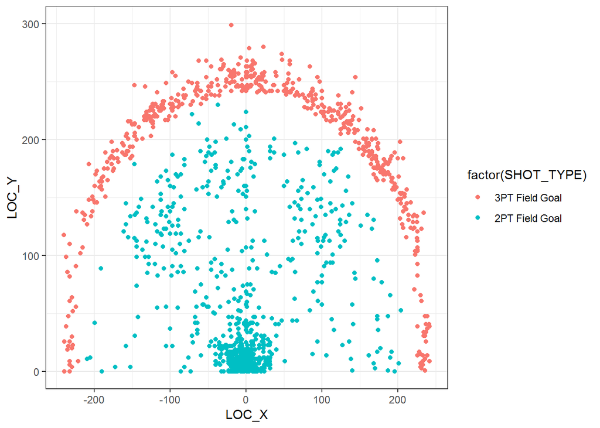

```r
library("ggplot2")
p3 <- ggplot(data=data) + geom_point(aes(x=LOC_X, y=LOC_Y, color=factor(SHOT_TYPE))) + ylim(c(0,300)) + theme_bw()
p3
```

#### a. Construct a Logistic Regression model to predict **SHOT_TYPE** using **LOC_X** and **LOC_Y** (because the boundary is a half circle, you will need 2nd-order polynomial for both X and Y). (1 point)

Note: since the 2-pointer and 3-pointer are perfectly separable, you may see warnings such as *glm.fit: algorithm did not converge* and *glm.fit: fitted probabilities numerically 0 or 1 occurred*. Do not worry about them.

*ANSWER of Q2a:*

```r
model2a <- glm(SHOT_TYPE~ poly(LOC_X,2,raw = TRUE)+poly(LOC_Y,2,raw = TRUE),family = "binomial",data)
```

```
## Warning: glm.fit: algorithm did not converge
```

```
## Warning: glm.fit: fitted probabilities numerically 0 or 1 occurred
```

```r
summary(model2a)
```

```
##
## Call:
## glm(formula = SHOT_TYPE ~ poly(LOC_X, 2, raw = TRUE) + poly(LOC_Y,
##     2, raw = TRUE), family = "binomial", data = data)
##
## Deviance Residuals:
##        Min          1Q      Median          3Q         Max
## -6.629e-04  -2.000e-08   2.000e-08   2.000e-08   5.670e-04
##
## Coefficients:
##                               Estimate Std. Error z value Pr(>|z|)
## (Intercept)                  5.441e+02  2.981e+04   0.018    0.985
## poly(LOC_X, 2, raw = TRUE)1  1.947e-02  2.758e+01   0.001    0.999
## poly(LOC_X, 2, raw = TRUE)2 -1.219e-02  6.367e-01  -0.019    0.985
## poly(LOC_Y, 2, raw = TRUE)1  1.249e+00  1.613e+02   0.008    0.994
## poly(LOC_Y, 2, raw = TRUE)2 -1.508e-02  9.165e-01  -0.016    0.987
##
## (Dispersion parameter for binomial family taken to be 1)
##
##     Null deviance: 1.9152e+03  on 1442  degrees of freedom
## Residual deviance: 1.1120e-06  on 1438  degrees of freedom
## AIC: 10
##
## Number of Fisher Scoring iterations: 25
```

Next, plot the boundary of the fitted Logistic Regression model on top of the previous plot. Like what we have done before, we need to create a grid on the basketball court and predict the class of each point on the grid. The following code does the creation of grid dataframe.

```r
data.grid <- expand.grid(LOC_X=seq(-250, 250), LOC_Y=seq(0, 300))
```

#### b. Make predictions on the new data **data.grid** using the Logistric Regression model we built in part (a), and plot the boundary on the previous plot (**p3**). (1 point)

*ANSWER of Q2b:*

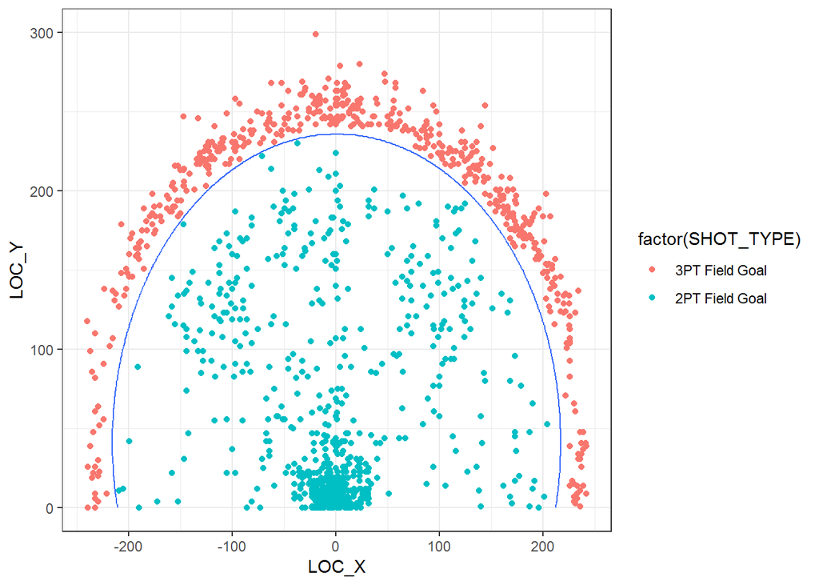

```r
#Make predictions on the new data
pred_2a <- predict(model2a,data.grid,type = 'response')
#plot the boundary on the previous plot
p3+stat_contour(data=data.grid, aes(x=LOC_X, y=LOC_Y, z=pred_2a), breaks=c(0.5))
```

### Q3. Analysis on **SHOT_RESULT** of 2-pointers (5 points)

In the following, we will try to predict the outcome of 2-point shots. We need to subset the data that only consists of 2-point shots.

```r
## split 3pt and 2pt
data2 <- subset(data, SHOT_TYPE=="2PT Field Goal")
```

In the rest of this question, we shall use **data2** as the dataset for analysis. Let’s visualize **SHOT_RESULT** by X, Y locations.

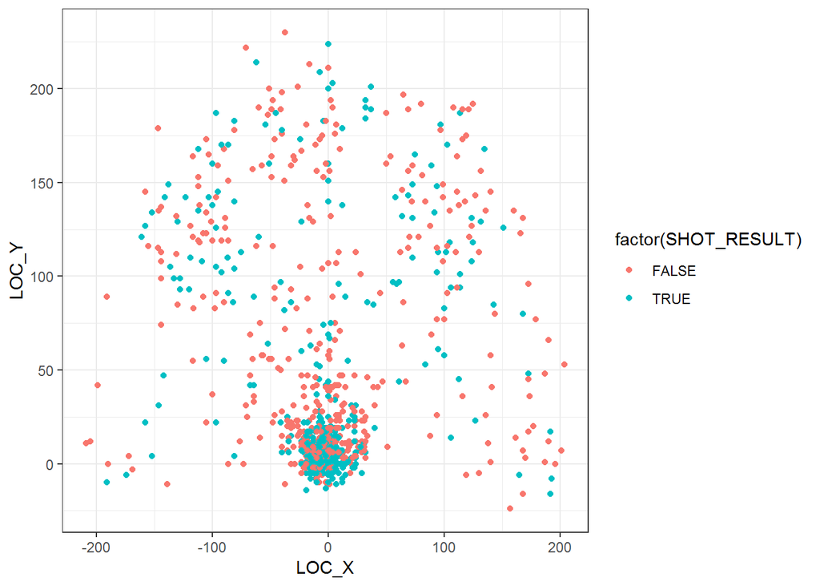

```r
ggplot(data=data2) + geom_point(aes(x=LOC_X, y=LOC_Y, color=factor(SHOT_RESULT))) + theme_bw()
```

#### a. Build a model to investigate the effect of **SHOT_DISTANCE** and **CLOSE_DEF_DIST** on **SHOT_RESULT**, and briefly interpret the coefficients that you obtain. (1 point)

*ANSWER of Q3a:*

```r
model3a <- glm(formula=SHOT_RESULT ~ CLOSE_DEF_DIST + SHOT_DISTANCE,data=data2, family ="binomial")
summary(model3a)
```

```
##
## Call:
## glm(formula = SHOT_RESULT ~ CLOSE_DEF_DIST + SHOT_DISTANCE, family = "binomial",
##     data = data2)
##
## Deviance Residuals:
##     Min       1Q   Median       3Q      Max
## -1.7205  -1.0971  -0.7366   1.1191   1.8996
##
## Coefficients:
##                Estimate Std. Error z value Pr(>|z|)
## (Intercept)    -0.34382    0.14736  -2.333   0.0196 *
## CLOSE_DEF_DIST  0.26845    0.04955   5.417 6.05e-08 ***
## SHOT_DISTANCE  -0.08283    0.01112  -7.446 9.64e-14 ***
## ---
## Signif. codes:  0 '***' 0.001 '**' 0.01 '*' 0.05 '.' 0.1 ' ' 1
##
## (Dispersion parameter for binomial family taken to be 1)
##
##     Null deviance: 1240.8  on 895  degrees of freedom
## Residual deviance: 1166.8  on 893  degrees of freedom
## AIC: 1172.8
##
## Number of Fisher Scoring iterations: 4
```

the coefficient of the two variables are all significant. The result shows that the farther the closest defender is, the SHOT_RESULT will more likely to be TRUE, the farther the SHOT_DISTANCE is, the SHOT_RESULT will more likely to be FALSE.

Finally, we will do some cross validation. But before we start, we need to tackle one problem. If you check the frequency of variable **ACTION_TYPE**,

```r
table(data2$ACTION_TYPE)
```

```
##
##                      Jump Shot                     Layup Shot             Driving Layup Shot
##                            151                            126                            288
##            Step Back Jump shot             Fadeaway Jump Shot              Running Jump Shot
##                            134                             27                             30
##               Pullup Jump shot                 Slam Dunk Shot             Running Layup Shot
##                             20                              8                              8
## Driving Finger Roll Layup Shot              Driving Bank shot                       Tip Shot
##                              5                              2                              8
##       Turnaround Fadeaway shot              Running Bank shot             Floating Jump shot
##                              6                              4                             12
##           Turnaround Jump Shot             Reverse Layup Shot                      Dunk Shot
##                              7                              0                             10
##             Putback Layup Shot         Driving Slam Dunk Shot              Driving Jump shot
##                              2                              6                             10
##     Driving Reverse Layup Shot               Pullup Bank shot              Driving Dunk Shot
##                              7                              2                              7
##           Turnaround Bank shot              Running Dunk Shot         Finger Roll Layup Shot
##                              2                              1                              2
##                 Jump Bank Shot         Running Slam Dunk Shot            Alley Oop Dunk Shot
##                              3                              1                              1
##           Alley Oop Layup shot              Running Hook Shot                      Hook Shot
##                              4                              1                              1
```

there are a lot of action types that only have several data points. They will become big trouble if we do cross validation. Let’s get rid of them by constructing a new variable **ACTION_TYPE2**, which only keeps those action types with at least 50 data points. All other types will be combined into one category called “others.” The following code will get the job done.

```r
levels.old <- levels(data2$ACTION_TYPE)
levels.new <- ifelse(table(data2$ACTION_TYPE) > 50, levels.old, "others")
data2$ACTION_TYPE2 <- data2$ACTION_TYPE
levels(data2$ACTION_TYPE2) <- levels.new
table(data2$ACTION_TYPE2)
```

```
##
##           Jump Shot          Layup Shot  Driving Layup Shot Step Back Jump shot              others
##                 151                 126                 288                 134                 197
```

```r
data2$ACTION_TYPE <- NULL
```

#### b. Build a maximum logistic regression model for predicting **SHOT_RESULT**. Among all the available variables, think about which variables should not be included in the model. Include all the reasonable ones. (1 point)

**Note**: For the sake of the test, let’s not consider polynomials, transformations, or interactions. Only choose the variables in their original forms.

*ANSWER of Q3b:*

```r
data3 <- subset(data2, select=c(-PLAYER_ID, -PLAYER_NAME, -TEAM_ID, -TEAM_NAME, -CLOSEST_DEFENDER,-SHOT_TYPE,-MATCHUP,-FINAL_MARGIN,-PTS,-GAME_ID,-MINUTES_REMAINING))
model3b <- glm(SHOT_RESULT ~., data3, family="binomial")
summary(model3b)
```

```
##
## Call:
## glm(formula = SHOT_RESULT ~ ., family = "binomial", data = data3)
##
## Deviance Residuals:
##      Min        1Q    Median        3Q       Max
## -2.28096  -0.72671  -0.00008   0.72939   2.91703
##
## Coefficients:
##                                        Estimate Std. Error z value Pr(>|z|)
## (Intercept)                          -1.876e+01  6.523e+03  -0.003 0.997705
## PERIOD2                               1.872e-01  3.600e-01   0.520 0.603155
## PERIOD3                              -2.419e-01  4.784e-01  -0.506 0.613037
## PERIOD4                               2.081e-01  6.799e-01   0.306 0.759530
## PERIOD5                               3.822e-01  1.435e+00   0.266 0.790036
## SHOT_NUMBER                          -2.351e-02  4.181e-02  -0.562 0.573875
## SECONDS_REMAINING                     6.097e-04  6.204e-03   0.098 0.921720
## SHOT_ZONE_BASICMid-Range             -2.708e-01  9.262e-01  -0.292 0.769973
## SHOT_ZONE_BASICIn The Paint (Non-RA) -8.209e-01  5.942e-01  -1.382 0.167110
## SHOT_ZONE_AREACenter(C)               7.450e-01  8.879e-01   0.839 0.401431
## SHOT_ZONE_AREALeft Side Center(LC)    9.568e-01  1.216e+00   0.787 0.431424
## SHOT_ZONE_AREARight Side Center(RC)   5.177e-01  8.316e-01   0.623 0.533558
## SHOT_ZONE_AREALeft Side(L)            4.418e-01  1.102e+00   0.401 0.688426
## SHOT_ZONE_RANGE16-24 ft.              9.605e-01  1.067e+00   0.900 0.368063
## SHOT_ZONE_RANGE8-16 ft.               1.123e+00  7.650e-01   1.468 0.142031
## SHOT_DISTANCE                        -1.154e-01  8.872e-02  -1.301 0.193291
## LOC_X                                 6.467e-04  3.969e-03   0.163 0.870566
## LOC_Y                                -7.001e-04  5.020e-03  -0.139 0.889083
## LOCATIONA                             7.481e-01  2.634e-01   2.840 0.004508 **
## WL                                   -5.755e-01  3.097e-01  -1.859 0.063089 .
## GAME_CLOCK                            2.066e-04  7.025e-04   0.294 0.768729
## SHOT_CLOCK                           -1.240e-02  2.137e-02  -0.580 0.561668
## DRIBBLES                              2.571e-02  5.503e-02   0.467 0.640418
## TOUCH_TIME                           -6.073e-02  6.854e-02  -0.886 0.375575
## CLOSEST_DEFENDER_PLAYER_ID1495        1.734e+01  6.523e+03   0.003 0.997879
## CLOSEST_DEFENDER_PLAYER_ID1717        1.647e+01  6.523e+03   0.003 0.997985
## CLOSEST_DEFENDER_PLAYER_ID1718        1.661e+01  6.523e+03   0.003 0.997969
## CLOSEST_DEFENDER_PLAYER_ID1890       -4.210e+00  9.224e+03   0.000 0.999636
## CLOSEST_DEFENDER_PLAYER_ID2034        1.659e+01  6.523e+03   0.003 0.997971
## CLOSEST_DEFENDER_PLAYER_ID2045        1.553e+01  6.523e+03   0.002 0.998100
```

[output cut: 254 more lines]

```
## CLOSE_DEF_DIST                        2.816e-01  7.958e-02   3.539 0.000402 ***
## ACTION_TYPE2Layup Shot                1.964e-01  5.761e-01   0.341 0.733200
## ACTION_TYPE2Driving Layup Shot        2.590e+00  5.440e-01   4.761 1.93e-06 ***
## ACTION_TYPE2Step Back Jump shot       2.120e+00  4.236e-01   5.005 5.59e-07 ***
## ACTION_TYPE2others                    2.173e+00  4.068e-01   5.342 9.20e-08 ***
## ---
## Signif. codes:  0 '***' 0.001 '**' 0.01 '*' 0.05 '.' 0.1 ' ' 1
##
## (Dispersion parameter for binomial family taken to be 1)
##
##     Null deviance: 1240.83  on 895  degrees of freedom
## Residual deviance:  737.78  on 607  degrees of freedom
## AIC: 1315.8
##
## Number of Fisher Scoring iterations: 17
```

*ANSWER of Q3c:*

```r
library("MASS")
model3c <- stepAIC(model3b, direction="backward")
```

```
## Start:  AIC=1315.78
## SHOT_RESULT ~ PERIOD + SHOT_NUMBER + SECONDS_REMAINING + SHOT_ZONE_BASIC +
##     SHOT_ZONE_AREA + SHOT_ZONE_RANGE + SHOT_DISTANCE + LOC_X +
##     LOC_Y + LOCATION + W + GAME_CLOCK + SHOT_CLOCK + DRIBBLES +
##     TOUCH_TIME + CLOSEST_DEFENDER_PLAYER_ID + CLOSE_DEF_DIST +
##     ACTION_TYPE2
##
##                               Df Deviance    AIC
## - CLOSEST_DEFENDER_PLAYER_ID 260  1056.00 1114.0
## - SHOT_ZONE_AREA               4   738.68 1308.7
## - PERIOD                       4   740.63 1310.6
## - SECONDS_REMAINING            1   737.79 1313.8
## - LOC_Y                        1   737.80 1313.8
## - LOC_X                        1   737.81 1313.8
## - GAME_CLOCK                   1   737.87 1313.9
## - DRIBBLES                     1   738.00 1314.0
## - SHOT_NUMBER                  1   738.10 1314.1
## - SHOT_ZONE_RANGE              2   740.11 1314.1
## - SHOT_CLOCK                   1   738.12 1314.1
## - TOUCH_TIME                   1   738.57 1314.6
## - SHOT_ZONE_BASIC              2   741.02 1315.0
## - SHOT_DISTANCE                1   739.48 1315.5
## <none>                             737.78 1315.8
## - W                            1   741.27 1317.3
## - LOCATION                     1   746.05 1322.0
## - CLOSE_DEF_DIST               1   752.16 1328.2
## - ACTION_TYPE2                 4   824.99 1395.0
##
## Step:  AIC=1114
## SHOT_RESULT ~ PERIOD + SHOT_NUMBER + SECONDS_REMAINING + SHOT_ZONE_BASIC +
##     SHOT_ZONE_AREA + SHOT_ZONE_RANGE + SHOT_DISTANCE + LOC_X +
##     LOC_Y + LOCATION + W + GAME_CLOCK + SHOT_CLOCK + DRIBBLES +
##     TOUCH_TIME + CLOSE_DEF_DIST + ACTION_TYPE2
##
##                     Df Deviance    AIC
## - SHOT_ZONE_AREA     4   1057.4 1107.4
## - PERIOD             4   1058.9 1108.9
## - GAME_CLOCK         1   1056.0 1112.0
## - SHOT_CLOCK         1   1056.1 1112.1
## - LOC_Y              1   1056.1 1112.1
```

[output cut: 207 more lines]

```
## - CLOSE_DEF_DIST   1   1090.2 1112.2
## - ACTION_TYPE2     4   1151.4 1167.4
##
## Step:  AIC=1088.63
## SHOT_RESULT ~ SHOT_ZONE_BASIC + SHOT_DISTANCE + LOCATION + TOUCH_TIME +
##     CLOSE_DEF_DIST + ACTION_TYPE2
##
##                   Df Deviance    AIC
## <none>                 1066.6 1088.6
## - SHOT_DISTANCE    1   1069.1 1089.1
## - TOUCH_TIME       1   1069.4 1089.4
## - SHOT_ZONE_BASIC  2   1072.5 1090.5
## - LOCATION         1   1075.9 1095.9
## - CLOSE_DEF_DIST   1   1091.4 1111.4
## - ACTION_TYPE2     4   1152.3 1166.3
```

```r
summary(model3c)
```

```
##
## Call:
## glm(formula = SHOT_RESULT ~ SHOT_ZONE_BASIC + SHOT_DISTANCE +
##     LOCATION + TOUCH_TIME + CLOSE_DEF_DIST + ACTION_TYPE2, family = "binomial",
##     data = data3)
##
## Deviance Residuals:
##     Min       1Q   Median       3Q      Max
## -1.8616  -0.9916  -0.4503   0.9876   2.3063
##
## Coefficients:
##                                      Estimate Std. Error z value Pr(>|z|)
## (Intercept)                          -1.77318    0.41769  -4.245 2.18e-05 ***
## SHOT_ZONE_BASICMid-Range              0.12777    0.60277   0.212  0.83212
## SHOT_ZONE_BASICIn The Paint (Non-RA) -0.53205    0.36928  -1.441  0.14965
## SHOT_DISTANCE                        -0.06013    0.03813  -1.577  0.11481
## LOCATIONA                             0.47073    0.15591   3.019  0.00253 **
## TOUCH_TIME                           -0.03002    0.01825  -1.645  0.09990 .
## CLOSE_DEF_DIST                        0.24884    0.05401   4.607 4.08e-06 ***
## ACTION_TYPE2Layup Shot                0.49226    0.39032   1.261  0.20725
## ACTION_TYPE2Driving Layup Shot        1.95866    0.36611   5.350 8.80e-08 ***
## ACTION_TYPE2Step Back Jump shot       1.55223    0.30567   5.078 3.81e-07 ***
## ACTION_TYPE2others                    1.69085    0.28835   5.864 4.52e-09 ***
## ---
## Signif. codes:  0 '***' 0.001 '**' 0.01 '*' 0.05 '.' 0.1 ' ' 1
##
## (Dispersion parameter for binomial family taken to be 1)
##
##     Null deviance: 1240.8  on 895  degrees of freedom
## Residual deviance: 1066.6  on 885  degrees of freedom
## AIC: 1088.6
##
## Number of Fisher Scoring iterations: 4
```

#### d. Build a LASSO model based on the maximum model we built in Q3b (run cross-validtion to do proper shrinkage). Print a summary of the model you have found at the end. (1 point)

*ANSWER of Q3d:*

```r
library("glmnetUtils")
# CV for optimal lambda
set.seed(456)
model3d <- cv.glmnet(SHOT_RESULT ~., data3, family="binomial",alpha=1, use.model.frame=TRUE)
# final model
coef(model3d,model3d$lambda.min)
```

```
## 330 x 1 sparse Matrix of class "dgCMatrix"
##                                                  1
## (Intercept)                          -1.4935156769
## PERIOD2                               .
## PERIOD3                               .
## PERIOD4                               .
## PERIOD5                               .
## SHOT_NUMBER                           .
## SECONDS_REMAINING                     .
## SHOT_ZONE_BASICRestricted Area        0.5633092816
## SHOT_ZONE_BASICAbove the Break 3      .
## SHOT_ZONE_BASICMid-Range              .
## SHOT_ZONE_BASICIn The Paint (Non-RA) -0.0769810749
## SHOT_ZONE_BASICLeft Corner 3          .
## SHOT_ZONE_BASICBackcourt              .
## SHOT_ZONE_AREACenter(C)               .
## SHOT_ZONE_AREALeft Side Center(LC)    .
## SHOT_ZONE_AREARight Side Center(RC)   .
## SHOT_ZONE_AREALeft Side(L)            .
## SHOT_ZONE_AREABack Court(BC)          .
## SHOT_ZONE_RANGELess Than 8 ft.        .
## SHOT_ZONE_RANGE16-24 ft.             -0.0475852177
## SHOT_ZONE_RANGE8-16 ft.               .
## SHOT_ZONE_RANGEBack Court Shot        .
## SHOT_DISTANCE                        -0.0002451014
## LOC_X                                 .
## LOC_Y                                 .
## LOCATIONA                             0.1079359597
## WL                                    .
## GAME_CLOCK                            .
## SHOT_CLOCK                            .
## DRIBBLES                              .
## TOUCH_TIME                           -0.0050846259
## CLOSEST_DEFENDER_PLAYER_ID1495        .
## CLOSEST_DEFENDER_PLAYER_ID1717        .
## CLOSEST_DEFENDER_PLAYER_ID1718        .
## CLOSEST_DEFENDER_PLAYER_ID1890       -0.3611028075
## CLOSEST_DEFENDER_PLAYER_ID1938        .
## CLOSEST_DEFENDER_PLAYER_ID2034        .
## CLOSEST_DEFENDER_PLAYER_ID2037        .
```

[output cut: 277 more lines]

```
## CLOSEST_DEFENDER_PLAYER_ID203940      .
## CLOSEST_DEFENDER_PLAYER_ID203943      0.1094913073
## CLOSEST_DEFENDER_PLAYER_ID203952      .
## CLOSEST_DEFENDER_PLAYER_ID203953      0.3629389665
## CLOSEST_DEFENDER_PLAYER_ID203955      .
## CLOSEST_DEFENDER_PLAYER_ID203957      .
## CLOSEST_DEFENDER_PLAYER_ID203994      .
## CLOSEST_DEFENDER_PLAYER_ID204037      .
## CLOSEST_DEFENDER_PLAYER_ID204038      .
## CLOSEST_DEFENDER_PLAYER_ID204060      .
## CLOSE_DEF_DIST                        0.1592151282
## ACTION_TYPE2Layup Shot                .
## ACTION_TYPE2Driving Layup Shot        1.1486420688
## ACTION_TYPE2Step Back Jump shot       0.4184246472
## ACTION_TYPE2others                    0.8057078069
```

#### e. Compare ROC curve and AUC of the three models obtained in Q3b, Q3c, and Q3d using the dataset **data2**, and briefly interpret the comparison. (1 point)

*ANSWER of Q3e:*

```r
library(dplyr)
pred3b <- predict(model3b,newdata=data2,type="response")
pred3c <- predict(model3c,newdata=data2,type="response")
pred3d <- predict(model3d, s=model3d$lambda.min, newdata=data2,type="response")
library(ROCR)
```

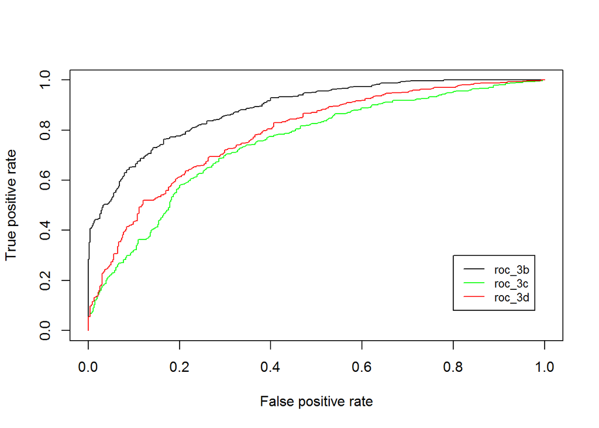

```r
pred.3b <- prediction(pred3b,data3$SHOT_RESULT)
pred.3c <- prediction(pred3c,data3$SHOT_RESULT)
pred.3d <- prediction(pred3d,data3$SHOT_RESULT)
#roc
roc_3b <- performance(pred.3b,"tpr","fpr")
roc_3c <- performance(pred.3c,"tpr","fpr")
roc_3d <- performance(pred.3d,"tpr","fpr")
#plot roc
plot(roc_3b,col="black")
plot(roc_3c,col="green",add=TRUE)
plot(roc_3d,col="red",add=TRUE)
legend(x=0.8,y=0.3,legend = c("roc_3b","roc_3c","roc_3d"),lty = c(1,1,1),lwd = c(1,1,1),col = c("black","green","red"),cex=0.8)
```

```r
#auc
performance(pred.3b,"auc")@y.values[[1]]
```

```
## [1] 0.8851284
```

```r
performance(pred.3c,"auc")@y.values[[1]]
```

```
## [1] 0.7468727
```

```r
performance(pred.3d,"auc")@y.values[[1]]
```

```
## [1] 0.7859142
```

the result shows that model 3B has the largest auc value.It may seem confusion as the maximum model get the largest auc, but it make sense in this case. It mainly because that we use train data to do the predict. As the stepAIC and lasso are all used to avoid overfitting, it is normal that they perform worse when to fit the train data *[THE END]*